# Evolution Poster

Diana Gao

2025-6-1

# Setup

## Load Packages

```r
library(tidyverse)
library(here)
library(janitor)
library(reshape2) # for working with matrices
library(phytools) # for working with phylo data
library(patchwork)
library(car)
library(ggResidpanel)
library(VGAM)
library(ggtree)

#functions
bmMLE <- function(phy, x) {
  #browser() is debug mode
    # calculate VCV matrix and inverse
    S <- ape::vcv(phy, model = 'Brownian', corr = FALSE)
    Sinv <- solve(S)

    # a vector of 1s for matrix math below
    one <- rep(1, nrow(Sinv))

    # MLE of trait value at root
    x0 <- as.vector(solve(one %*% Sinv %*% one) %*% (one %*% Sinv %*% x))

    # MLE of BM variance
    s2 <- as.vector(((x - x0) %*% Sinv %*% (x - x0)) / nrow(Sinv))

    return(list(x0 = x0, s2 = s2, Smat = s2 * S))
}
```

### Load data

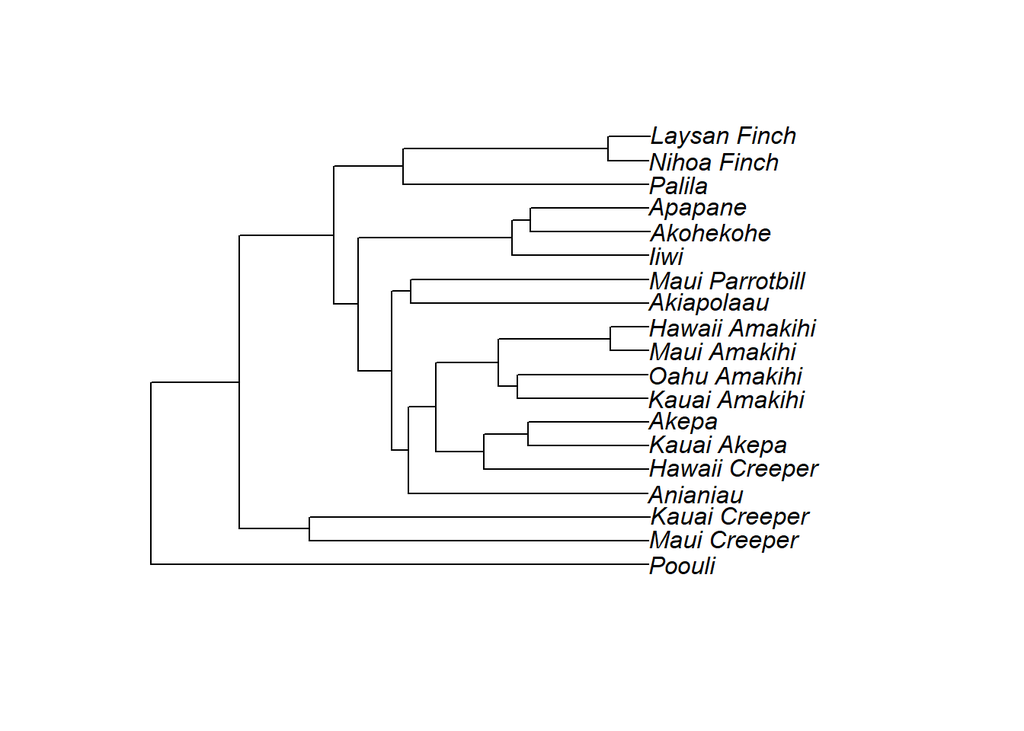

```r
names <- read_csv(here("data", "Honeycreeper_info.csv")) # gathered honeycreeper info
data_3d <- read_csv(here("data", "clean_morpho_diet.csv")) # data from mosleh et al

# tree from lerner et al
tree_name <- file.path(here("data", "Lerner_etal_2011_CurrBio_honeycreepers_mod.newick"))
tree <- read.newick(tree_name)
plot(tree) # test that the tree read in correctly
```

# Cleaning

```r
# clean self-generated creeper info --------------
names_clean <- names %>%
  clean_names()
#first, change sci names to full--------------------------
data_3d <- data_3d %>%
  mutate(across(species,
         ~ ifelse(. == "C. flava", "Chlorodrepanis flava", .))) %>%
  mutate(across(species,
         ~ ifelse(. == "C. stejnegeri", "Chlorodrepanis stejnegeri", .))) %>%
  mutate(across(species,
         ~ ifelse(. == "C. virens", "Chlorodrepanis virens", .))) %>%
  mutate(across(species,
         ~ ifelse(. == "H. sanguinea", "Himatione sanguinea", .))) %>%
  mutate(across(species,
         ~ ifelse(. == "H. wilsoni", "Hemignathus wilsoni", .))) %>%
  mutate(across(species,
         ~ ifelse(. == "L. bailleui", "Loxioides bailleui", .))) %>%
  mutate(across(species,
         ~ ifelse(. == "L. caeruleirostris", "Loxops caeruleirostris", .))) %>%
  mutate(across(species,
         ~ ifelse(. == "L. coccineus", "Loxops coccineus", .))) %>%
  mutate(across(species,
         ~ ifelse(. == "M. mana", "Manucerthia mana", .))) %>%
  mutate(across(species,
         ~ ifelse(. == "M. parva", "Magumma parva", .))) %>%
  mutate(across(species,
         ~ ifelse(. == "M. phaeosoma", "Melamprosops phaeosoma", .))) %>%
  mutate(across(species,
         ~ ifelse(. == "O. bairdi", "Oreomystis bairdi", .))) %>%
  mutate(across(species,
         ~ ifelse(. == "P. dolei", "Palmeria dolei", .))) %>%
  mutate(across(species,
         ~ ifelse(. == "P. montana", "Paroreomyza montana", .))) %>%
  mutate(across(species,
         ~ ifelse(. == "P. xanthophrys", "Pseudonestor xanthophrys", .))) %>%
  mutate(across(species,
         ~ ifelse(. == "T. cantans", "Telespiza cantans", .))) %>%
  mutate(across(species,
         ~ ifelse(. == "T. ultima", "Telespiza ultima", .))) %>%
  mutate(across(species,
         ~ ifelse(. == "V. coccinea", "Drepanis coccinea", .)))# Vestiaria coccinea = Drepanis coccinea

# now join with names
morpho_3d <- data_3d %>%
  rename(sci_name = species) %>%
  inner_join(names_clean, by = "sci_name") %>%
  select(sci_name, hi_name, common_name, diet.y, detailed_diet, width_2length:diet.x) %>%
  mutate(common_name = coalesce(common_name, hi_name)) %>% # coalesce (frm dplyr) is good for replacing NAs with values from other vectors. if there is a missing common name, use the name from the hi_name column
  mutate(common_name = str_replace_all(common_name, "`", "")) %>% # get rid of tone markings so it can match the names from the phylo
  mutate(common_name = str_replace_all(common_name, "ō", "o")) %>%
  mutate(common_name = str_replace_all(common_name, "ā", "a"))
```

# Dist Matrix Making

## Morphological data

```r
# clean up names----------------
morpho_3d <- morpho_3d %>%
  mutate(common_name = str_replace_all(common_name, " ", "_")) %>%
  mutate(common_name = str_replace_all(common_name, "Lesser_Amakihi", "Anianiau")) %>% # the phylo used diff names for these T_T
  mutate(common_name = str_replace_all(common_name, "Hawaii_akepa", "Akepa")) %>%
  mutate(common_name = str_replace_all(common_name, "Crested_honeycreeper", "Akohekohe"))

# sharpening rate (s)---------------------
s_3d <- morpho_3d %>%
  select(common_name, S_norm) %>%
  group_by(common_name) %>%
  summarise(mean_s_norm = mean(S_norm)) %>% # s_norm is S~, the dimensionless S (normalized against beak scale)
  mutate(mean_s_norm = scale(mean_s_norm)) # z transform
###  now actually make matrix
# setup
s_matrix=dist(s_3d)
s_matrix=as.matrix(s_matrix, labels=TRUE)
colnames(s_matrix) <- rownames(s_matrix) <- s_3d[['common_name']] #this is the  line to store sp names
# make matrix now
cleaned_s_dist <- s_matrix %>%
  melt() %>%
  filter(Var1 != Var2) %>%
  mutate(Var1 = str_to_lower(Var1)) %>% # make everything lowercase to make the matching easier
  mutate(Var2 = str_to_lower(Var2)) %>%
  rename(s_dist = value) %>%
  mutate(A_standard = pmin(Var1, Var2), B_standard = pmax(Var1, Var2)) %>% # create temp columns for sorting purposes, with A always having the name that is first alphabetically
  distinct(A_standard, B_standard, .keep_all = TRUE) %>% # only keep columns with distinct columns of A and B, which should both be sorted/factored so that dupes have the same A and B col
  mutate(pair = paste(A_standard, ",", B_standard)) %>% # make 1 col w both pair names
  mutate(pair = str_replace_all(pair, " ", "")) %>%
  select(s_dist, Var1, Var2, pair)

# Wc/(2Lc) -----------------
### clean and average the multiple specimens per sp
W_2L_3d <- morpho_3d %>%
  select(common_name, width_2length) %>%
  group_by(common_name) %>%
  summarise(mean_width_2length = mean(width_2length)) %>% # s_norm is S~, the dimensionless S (normalized against beak scale)
  mutate(mean_width_2length = scale(mean_width_2length)) # z transform
###  now actually make matrix
# setup
W_2L_matrix=dist(W_2L_3d)
W_2L_matrix=as.matrix(W_2L_matrix, labels=TRUE)
colnames(W_2L_matrix) <- rownames(W_2L_matrix) <- W_2L_3d[['common_name']] #this is the line that keeps the sp names
# make matrix now
cleaned_W_2L_dist <- W_2L_matrix %>%
  melt() %>%
  filter(Var1 != Var2) %>%
  mutate(Var1 = str_to_lower(Var1)) %>% # make everything lowercase to make the matching easier
  mutate(Var2 = str_to_lower(Var2)) %>%
  rename(W_2L_dist = value) %>%
  mutate(A_standard = pmin(Var1, Var2), B_standard = pmax(Var1, Var2)) %>% # create temp columns for sorting purposes, with A always having the name that is first alphabetically
  distinct(A_standard, B_standard, .keep_all = TRUE) %>% # only keep columns with distinct columns of A and B, which should both be sorted/factored so that dupes have the same A and B col
  mutate(pair = paste(A_standard, ",", B_standard)) %>% # make 1 col w both pair names
  mutate(pair = str_replace_all(pair, " ", "")) %>%
  select(W_2L_dist, Var1, Var2, pair)
```

## Phylogenetic data

```r
#generate phylo pairwise dist matrix
phylo_dist <- cophenetic.phylo(tree)

# cleaning for mosleh et al ------
phylo_dist_3d <- phylo_dist %>%
  melt() %>%
  filter(Var1 != Var2) %>%
  filter(Var1 != "Maui_Amakihi") %>% # no morpho data for maui amakihi, remove
  filter(Var2 != "Maui_Amakihi") %>%
  mutate(Var1 = str_to_lower(Var1)) %>% # make everything lowercase to make the matching easier
  mutate(Var2 = str_to_lower(Var2)) %>%
  rename(phylo_dist = value) %>%
  mutate(A_standard = pmin(Var1, Var2), B_standard = pmax(Var1, Var2)) %>% # create temp columns for sorting purposes, with A always having the name that is first alphabetically
  distinct(A_standard, B_standard, .keep_all = TRUE) %>% # only keep columns with distinct columns of A and B, which should both be sorted/factored so that dupes have the same A and B col
  mutate(pair = paste(A_standard, ",", B_standard)) %>% # make 1 col w both pair names
  mutate(pair = str_replace_all(pair, " ", "")) %>%
  select(phylo_dist, Var1, Var2, pair)
```

## Joining phylo data to morpho data

```r
# s-----------------------
s_3d_phylo <- cleaned_s_dist %>%
  left_join(phylo_dist_3d, by = join_by(pair)) %>%
  mutate(A_standard = pmin(Var1.x, Var2.x), B_standard = pmax(Var1.x, Var2.x)) %>% # create temp columns for sorting purposes, with A always having the name that is first alphabetically
  distinct(A_standard, B_standard, .keep_all = TRUE) %>% # only keep columns with distinct columns of A and B, which should both be sorted/factored so that dupes have the same A and B col
  select(pair, s_dist, phylo_dist)

#Wc/2Lc -----------------
W_2L_3d_phylo <- cleaned_W_2L_dist %>%
  left_join(phylo_dist_3d, by = join_by(pair)) %>%
  mutate(A_standard = pmin(Var1.x, Var2.x), B_standard = pmax(Var1.x, Var2.x)) %>% # create temp columns for sorting purposes, with A always having the name that is first alphabetically
  distinct(A_standard, B_standard, .keep_all = TRUE) %>% # only keep columns with distinct columns of A and B, which should both be sorted/factored so that dupes have the same A and B col
  select(pair, W_2L_dist, phylo_dist)
```

# Brownian Null

## Generating 95% quantile for morpho data based on brownian null

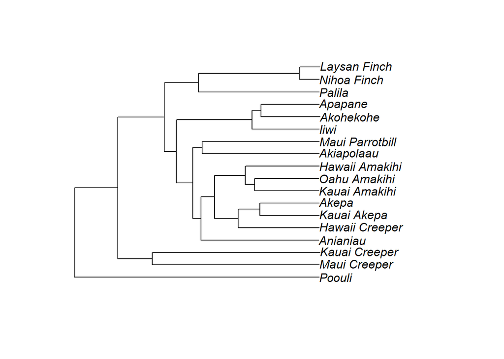

```r
# trim out maui amakihi
tree_3d <- tree %>%
  drop.tip("Maui_Amakihi")
# trying vgam function to extract
#Quantiles corresponding to cumulative proportions of a distribution. E.g., the 95% quantile is the value for which 95% of the data will be smaller than that value.
# folded normal dist (normal dist of abs value) 95% quantile

plot(tree_3d)
```

```r
# s----------------------------
# first bm quantile generation
s_sd <- bmMLE(tree_3d, as.vector(s_3d$mean_s_norm))
bm_s <- qfoldnorm(0.95, mean = 0, sd = sqrt(phylo_dist_3d$phylo_dist * s_sd$s2)) # sd of the data might be overestimated if pulled frmo real data, try vcv to see if this changes anything
bm_s <- data.frame(phylo_dist = phylo_dist_3d$phylo_dist,
                        morpho_dist = bm_s,
                        pair = phylo_dist_3d$pair)

# W/2L --------------
# first bm quantile generation
W_2L_sd <- bmMLE(tree_3d, as.vector(W_2L_3d$mean_width_2length))
bm_W_2L <- qfoldnorm(0.95, mean = 0, sd = sqrt(phylo_dist_3d$phylo_dist * W_2L_sd$s2))
bm_W_2L <- data.frame(phylo_dist = phylo_dist_3d$phylo_dist,
                        morpho_dist = bm_W_2L,
                        pair = phylo_dist_3d$pair)
```

### Plotting real data with brownian quantile overlay:

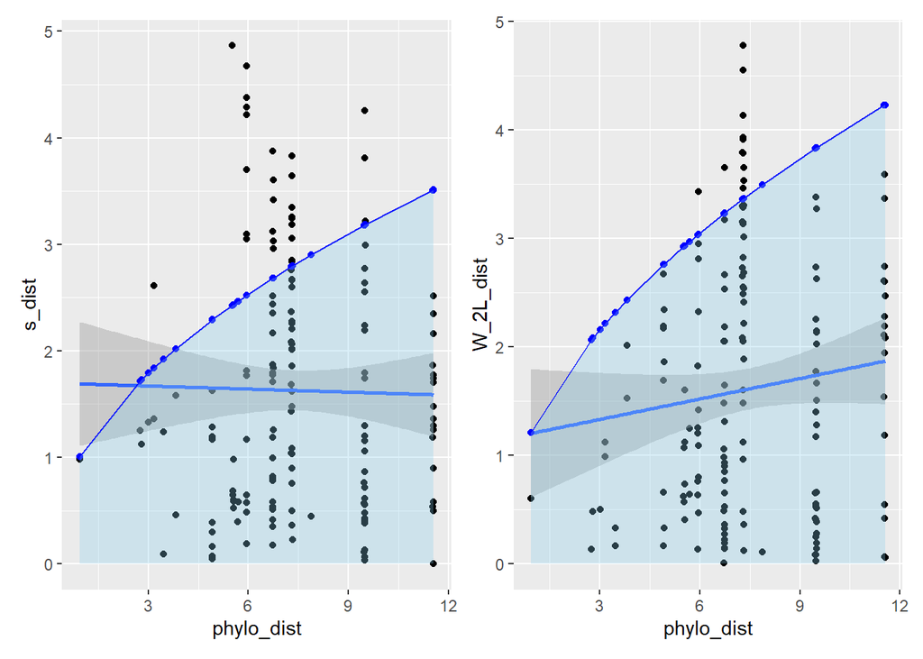

```r
combined <- ggplot() +
  # s -----------------------
  geom_point(s_3d_phylo, mapping = aes(x = phylo_dist, y = s_dist))+
  geom_smooth(s_3d_phylo, mapping = aes(x = phylo_dist, y = s_dist), method = 'lm') +
  geom_point(bm_s, mapping = aes(x = phylo_dist, y = morpho_dist), color = "blue") +
  geom_line(bm_s, mapping = aes(x = phylo_dist, y = morpho_dist), color = "blue") +
  geom_area(bm_s, mapping = aes(x = phylo_dist, y = morpho_dist), fill = "skyblue", alpha = .3) +
  # W/2L -------------------
  ggplot() +
  geom_point(W_2L_3d_phylo, mapping = aes(x = phylo_dist, y = W_2L_dist)) +
  geom_smooth(W_2L_3d_phylo, mapping = aes(x = phylo_dist, y = W_2L_dist), method = 'lm') +
  geom_point(bm_W_2L, mapping = aes(x = phylo_dist, y = morpho_dist), color = "blue") +
  geom_line(bm_W_2L, mapping = aes(x = phylo_dist, y = morpho_dist), color = "blue") +
  geom_area(bm_W_2L, mapping = aes(x = phylo_dist, y = morpho_dist), fill = "skyblue", alpha = .3)


combined
```

#### Selecting points above the quantile line

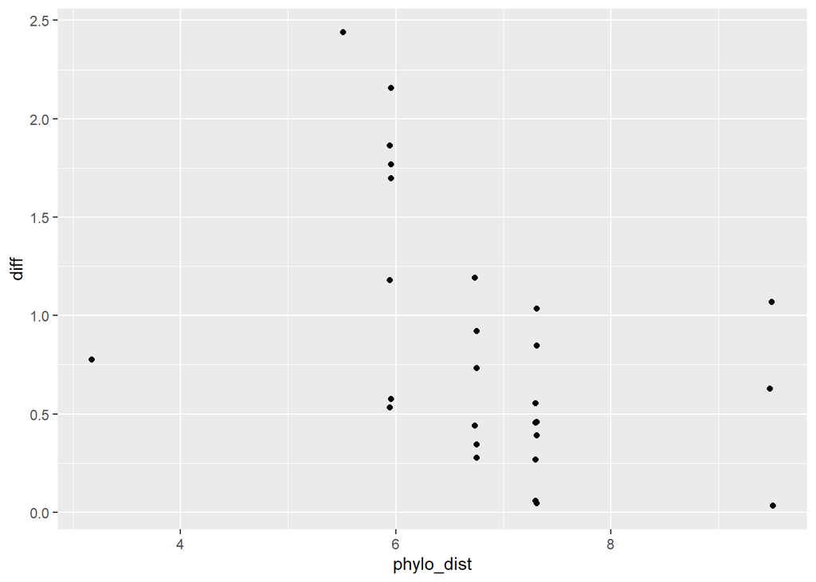

```r
# s ---------------------------
s_greater_than_bm <- s_3d_phylo %>%
  inner_join(bm_s, by = join_by(phylo_dist)) %>%
  filter(s_dist > morpho_dist) %>%
  select(!pair.y) %>%
  mutate(diff = (s_dist - morpho_dist)) %>%
  distinct()

# plot phylo_dist and greatest diff, basically zooming in to the points that are above line
ggplot(s_greater_than_bm, aes(x = phylo_dist, y = diff)) +
  geom_point()
```

```r
# sum the diff each sp has
s_greater_bm_by_sp <- s_greater_than_bm %>%
  separate(col = pair.x, into = c("sp1", "sp2"), sep = ",") %>%
  mutate(sp_a = pmin(sp1, sp2), sp_b = pmax(sp1, sp2)) %>%
  select(!c(sp1, sp2)) %>%
  pivot_longer(cols = c(sp_a, sp_b), names_to = "role", values_to = "sp") %>%
  group_by(sp) %>%
  summarise(diff = sum(diff), .groups = "drop")

s_greater_bm_by_sp
```

| sp | diff |
| --- | --- |
| akepa | 0.57442102 |
| akiapolaau | 15.09877201 |
| akohekohe | 3.49023084 |
| anianiau | 1.18003098 |
| hawaii_amakihi | 2.57111650 |
| hawaii_creeper | 4.00392972 |
| iiwi | 2.01028126 |
| kauai_akepa | 2.36399547 |
| kauai_amakihi | 2.85574697 |
| kauai_creeper | 1.10130507 |

[output cut: 6 more lines]

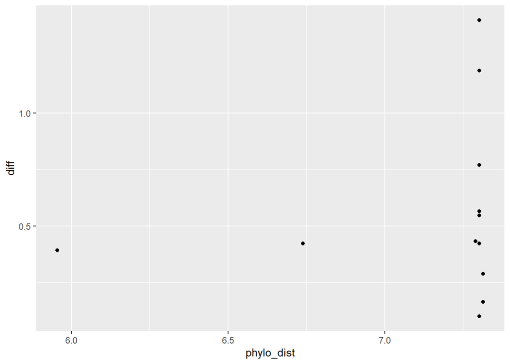

```r
# w/2l ----------------------
W_2L_greater_than_bm <- W_2L_3d_phylo %>%
  inner_join(bm_W_2L, by = join_by(phylo_dist)) %>%
  filter(W_2L_dist > morpho_dist) %>%
  select(!pair.y) %>%
  mutate(diff = (W_2L_dist - morpho_dist)) %>%
  distinct()

# plot phylo_dist and greatest diff, basically zooming in to the points that are above line
ggplot(W_2L_greater_than_bm, aes(x = phylo_dist, y = diff)) +
  geom_point()
```

```r
# sum the diff each sp has
W_2L_greater_bm_by_sp <- W_2L_greater_than_bm %>%
  separate(col = pair.x, into = c("sp1", "sp2"), sep = ",") %>%
  mutate(sp_a = pmin(sp1, sp2), sp_b = pmax(sp1, sp2)) %>%
  select(!c(sp1, sp2)) %>%
  pivot_longer(cols = c(sp_a, sp_b), names_to = "role", values_to = "sp") %>%
  group_by(sp) %>%
  summarise(diff = sum(diff), .groups = "drop")

W_2L_greater_bm_by_sp
```

| sp | diff |
| --- | --- |
| akiapolaau | 2.12648783 |
| akohekohe | 0.28895397 |
| apapane | 0.42259585 |
| hawaii_amakihi | 0.09962296 |
| iiwi | 2.76927682 |
| kauai_akepa | 0.81449138 |
| kauai_amakihi | 0.43335765 |
| laysan_finch | 0.16449631 |
| maui_parrotbill | 0.56603985 |
| nihoa_finch | 1.31674092 |

[output cut: 1 more lines]

#### Diff per diet

```r
morpho_3d_diet <- morpho_3d %>%
  mutate(sp = str_to_lower(common_name)) %>%
  select(sp, diet.x) %>% #setup data to be joined to s data
  distinct()

# s------------------------------
s_greater_bm_diet <- s_greater_than_bm %>%
  separate(col = pair.x, into = c("sp1", "sp2"), sep = ",") %>%
  mutate(sp_a = pmin(sp1, sp2), sp_b = pmax(sp1, sp2)) %>%
  select(!c(sp1, sp2)) %>%
  pivot_longer(cols = c(sp_a, sp_b), names_to = "role", values_to = "sp") %>%
  left_join(morpho_3d_diet) %>%
  group_by(diet.x) %>%
  summarise(diff_sum = sum(diff), num_sp = n_distinct(sp), stdev = sd(diff)) %>%
  mutate(avg_diff = diff_sum/num_sp)

# W/2L---------------------------
W_2L_bm_by_diet <- W_2L_greater_than_bm %>%
  separate(col = pair.x, into = c("sp1", "sp2"), sep = ",") %>%
  mutate(sp_a = pmin(sp1, sp2), sp_b = pmax(sp1, sp2)) %>%
  select(!c(sp1, sp2)) %>%
  pivot_longer(cols = c(sp_a, sp_b), names_to = "role", values_to = "sp") %>%
  left_join(morpho_3d_diet) %>%
  group_by(diet.x) %>%
  summarise(diff_sum = sum(diff), num_sp = n_distinct(sp), stdev = sd(diff)) %>%
  mutate(avg_diff = diff_sum/num_sp) # only 1 insectivore, maui parrotbill with palila

W_2L_greater_bm_by_sp$sp # these are the sp significantly diff from BM
```

```
##  [1] "akiapolaau"      "akohekohe"       "apapane"         "hawaii_amakihi"
##  [5] "iiwi"            "kauai_akepa"     "kauai_amakihi"   "laysan_finch"
##  [9] "maui_parrotbill" "nihoa_finch"     "palila"
```

### Plotting diff per diet

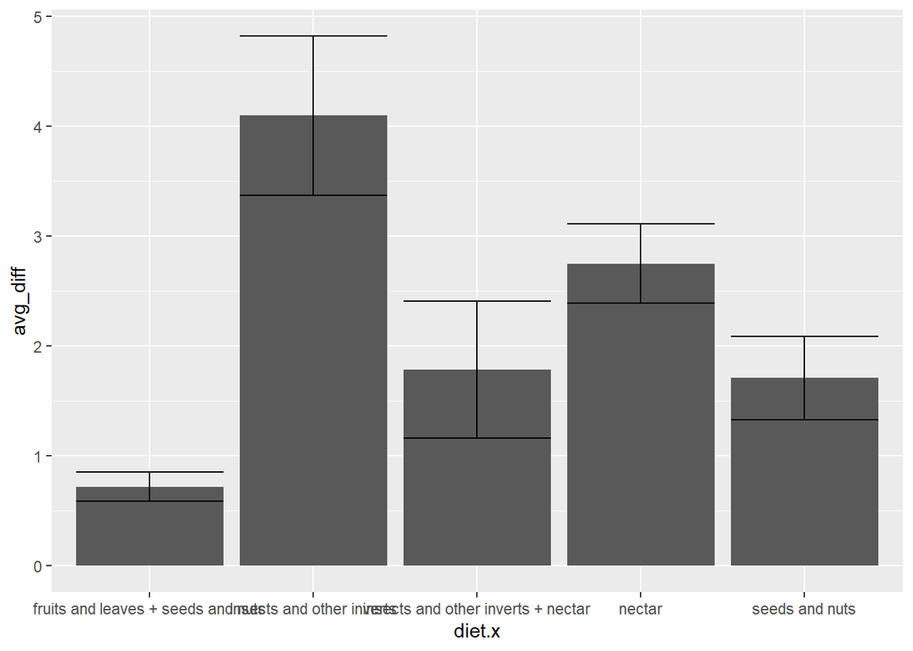

```r
# s-------------------------
ggplot(s_greater_bm_diet, aes(x = diet.x, y = avg_diff)) +
  geom_col() +
  geom_errorbar(aes(ymin = (avg_diff - stdev), ymax = (avg_diff + stdev)))
```

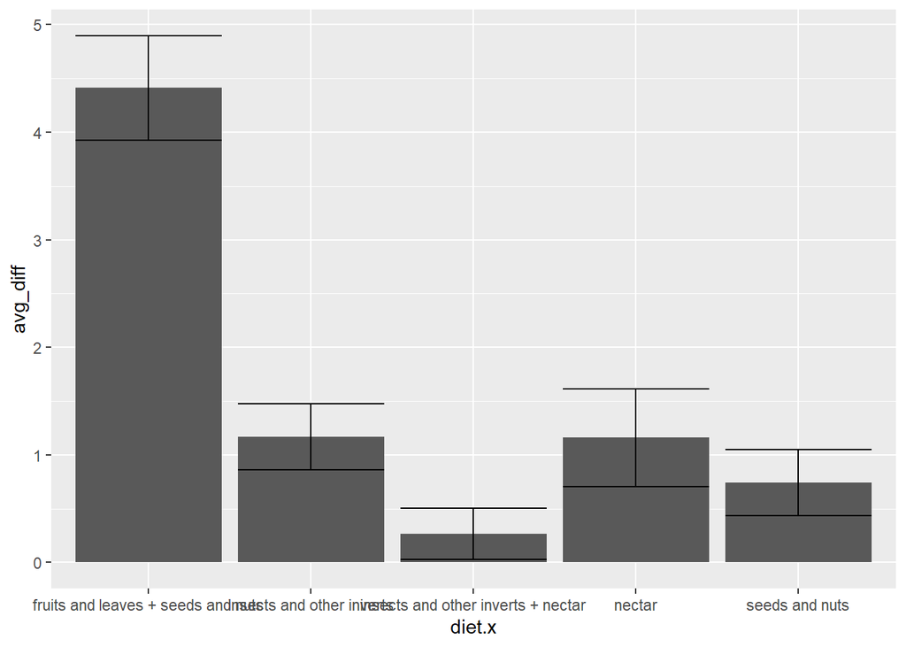

```r
# W/2L ----------------------
ggplot(W_2L_bm_by_diet, aes(x = diet.x, y = avg_diff)) +
  geom_col() +
  geom_errorbar(aes(ymin = (avg_diff - stdev), ymax = (avg_diff + stdev)))
```

using the mosleh et al classificaiton of diet, there is a slightly more even spread for s, but for w/2l not so much.

notes: find trendline for the BM model which taxa are outliers directionality bin ,create syndromes

## Simulating morpho data according to brownian null

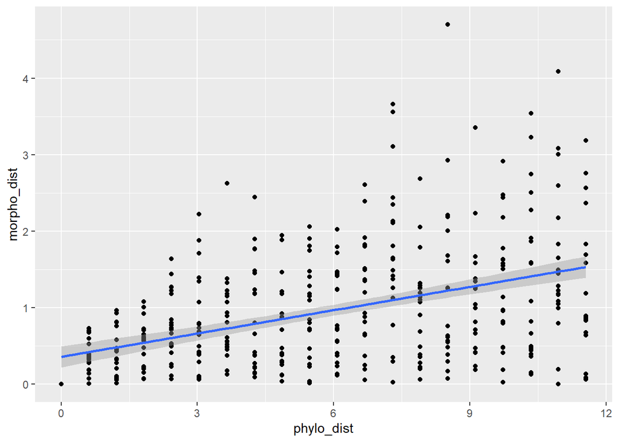

```r
# s---------------------------------------
nsim = 20 #sample.size = how many values to generate at each time step
time = seq(0, 11.552685, length.out = 20) #nsim = 10 equidistent time steps (defined by length.out)
# greatest phyol_dist is 11.552685)

# Setup storage matrix: rows = time points, columns = simulations
morpho_dist_matrix <- matrix(nrow = length(time), ncol = nsim)

# Loop by index, not value
for (i in seq_along(time)) {
  # simulate 20 values using fold norm distribution
  test <- rfoldnorm(nsim, mean = 0, sd = sqrt(time[i] * s_sd$s2))

  # Save to row i of the matrix
  morpho_dist_matrix[i, ] <- test
}


morpho_df_s <- as.data.frame(morpho_dist_matrix)
rownames(morpho_df_s) <- paste0("time_", round(time, 2))
colnames(morpho_df_s) <- paste0("sim_", 1:nsim)

morpho_sim_s <- morpho_df_s %>%
  mutate(across(everything(), ~replace_na(., 0))) %>%
  rownames_to_column() %>%
  mutate(time = rowname) %>%
  pivot_longer(cols = sim_1:sim_20) %>%
  mutate(time = str_remove(time, "time_")) %>%
  select(!rowname) %>%
  rename(phylo_dist = time, morpho_dist = value) %>%
  mutate(phylo_dist = as.numeric(phylo_dist))

# test plot:
ggplot(morpho_sim_s, aes(x = phylo_dist, y = morpho_dist))+
  geom_point() +
  geom_smooth(method = "lm")
```

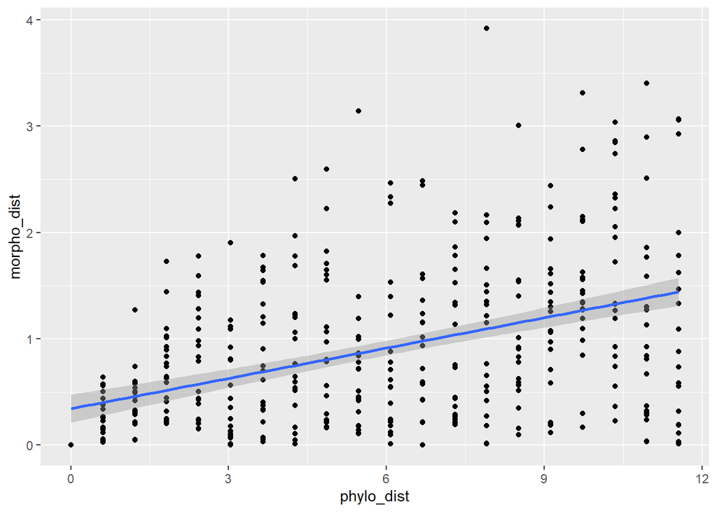

```r
# W/2L---------------------------------------
nsim = 20 #sample.size = how many values to generate at each time step
time = seq(0, 11.552685, length.out = 20) #nsim = 10 equidistant time steps (defined by length.out)
# greatest phyol_dist is 11.552685)

# Setup storage matrix: rows = time points, columns = simulations
morpho_dist_matrix <- matrix(nrow = length(time), ncol = nsim)

# Loop by index, not value
for (i in seq_along(time)) {
  # simulate 20 values using fold norm distribution
  test <- rfoldnorm(nsim, mean = 0, sd = sqrt(time[i] * s_sd$s2))

  # Save to row i of the matrix
  morpho_dist_matrix[i, ] <- test
}


morpho_df_W_2L <- as.data.frame(morpho_dist_matrix)
rownames(morpho_df_W_2L) <- paste0("time_", round(time, 2))
colnames(morpho_df_W_2L) <- paste0("sim_", 1:nsim)

morpho_sim_W_2L <- morpho_df_W_2L %>%
  mutate(across(everything(), ~replace_na(., 0))) %>%
  rownames_to_column() %>%
  mutate(time = rowname) %>%
  pivot_longer(cols = sim_1:sim_20) %>%
  mutate(time = str_remove(time, "time_")) %>%
  select(!rowname) %>%
  rename(phylo_dist = time, morpho_dist = value) %>%
  mutate(phylo_dist = as.numeric(phylo_dist))

# test plot:
ggplot(morpho_sim_W_2L, aes(x = phylo_dist, y = morpho_dist))+
  geom_point() +
  geom_smooth(method = "lm")
```

## Analysis/comparison of brownian to real data (lm)

### Slope comparison 1:1

```r
# s==================================
# real data -------------------------
mod_s <- lm(s_dist ~ phylo_dist, data = s_3d_phylo)
summary(mod_s)
```

```
##
## Call:
## lm(formula = s_dist ~ phylo_dist, data = s_3d_phylo)
##
## Residuals:
##     Min      1Q  Median      3Q     Max
## -1.6082 -1.0378 -0.2931  0.8052  3.2184
##
## Coefficients:
##              Estimate Std. Error t value Pr(>|t|)
## (Intercept)  1.699308   0.333431   5.096 1.02e-06 ***
## phylo_dist  -0.009595   0.042850  -0.224    0.823
## ---
## Signif. codes:  0 '***' 0.001 '**' 0.01 '*' 0.05 '.' 0.1 ' ' 1
##
## Residual standard error: 1.17 on 151 degrees of freedom
## Multiple R-squared:  0.0003319,  Adjusted R-squared:  -0.006288
## F-statistic: 0.05014 on 1 and 151 DF,  p-value: 0.8231
```

```r
# BM sim data -----------------------
mod_s_bm <- lm(morpho_dist ~ phylo_dist, data = morpho_sim_s)
summary(mod_s_bm)
```

```
##
## Call:
## lm(formula = morpho_dist ~ phylo_dist, data = morpho_sim_s)
##
## Residuals:
##     Min      1Q  Median      3Q     Max
## -1.4703 -0.4699 -0.1099  0.3840  3.4763
##
## Coefficients:
##             Estimate Std. Error t value Pr(>|t|)
## (Intercept)  0.35877    0.07024   5.108 5.07e-07 ***
## phylo_dist   0.10165    0.01040   9.778  < 2e-16 ***
## ---
## Signif. codes:  0 '***' 0.001 '**' 0.01 '*' 0.05 '.' 0.1 ' ' 1
##
## Residual standard error: 0.7289 on 398 degrees of freedom
## Multiple R-squared:  0.1937, Adjusted R-squared:  0.1917
## F-statistic: 95.61 on 1 and 398 DF,  p-value: < 2.2e-16
```

```r
# W/2L ==============================
# real data -------------------------
mod_W_2L <- lm(W_2L_dist ~ phylo_dist, data = W_2L_3d_phylo)
summary(mod_W_2L)
```

```
##
## Call:
## lm(formula = W_2L_dist ~ phylo_dist, data = W_2L_3d_phylo)
##
## Residuals:
##     Min      1Q  Median      3Q     Max
## -1.8099 -1.0749 -0.2227  0.8874  3.1725
##
## Coefficients:
##             Estimate Std. Error t value Pr(>|t|)
## (Intercept)  1.14400    0.33746   3.390 0.000892 ***
## phylo_dist   0.06269    0.04337   1.446 0.150346
## ---
## Signif. codes:  0 '***' 0.001 '**' 0.01 '*' 0.05 '.' 0.1 ' ' 1
##
## Residual standard error: 1.184 on 151 degrees of freedom
## Multiple R-squared:  0.01365,    Adjusted R-squared:  0.007119
## F-statistic:  2.09 on 1 and 151 DF,  p-value: 0.1503
```

```r
# BM sim data -----------------------
mod_W_2L_bm <- lm(morpho_dist ~ phylo_dist, data = morpho_sim_W_2L)
summary(mod_W_2L_bm)
```

```
##
## Call:
## lm(formula = morpho_dist ~ phylo_dist, data = morpho_sim_W_2L)
##
## Residuals:
##     Min      1Q  Median      3Q     Max
## -1.4288 -0.4465 -0.1325  0.3835  2.8239
##
## Coefficients:
##             Estimate Std. Error t value Pr(>|t|)
## (Intercept) 0.342699   0.067348   5.088 5.57e-07 ***
## phylo_dist  0.095138   0.009968   9.545  < 2e-16 ***
## ---
## Signif. codes:  0 '***' 0.001 '**' 0.01 '*' 0.05 '.' 0.1 ' ' 1
##
## Residual standard error: 0.6989 on 398 degrees of freedom
## Multiple R-squared:  0.1863, Adjusted R-squared:  0.1842
## F-statistic:  91.1 on 1 and 398 DF,  p-value: < 2.2e-16
```

### Probability dist. of brownian slopes

```r
# s---------------------------------------
nsim = 20 #sample.size = how many values to generate at each time step
time = seq(0, 11.552685, length.out = 20) #nsim = 10 equidistent time steps (defined by length.out)
# greatest phyol_dist is 11.552685)

runs = 2000 # how many times to run sim -> extract slope from it

# Setup storage vectors
int_save_s = coef_save_s = numeric(runs)

for (k in 1:runs) {
  for (i in seq_along(time)) {
    # simulate 20 values using fold norm distribution
    test <- rfoldnorm(nsim, mean = 0, sd = sqrt(time[i] * s_sd$s2))

    # Save to row i of the matrix
    morpho_dist_matrix[i, ] <- test

  }
  # store row/col names
  morpho_df_s <- as.data.frame(morpho_dist_matrix)
  rownames(morpho_df_s) <- paste0("time_", round(time, 2))
  colnames(morpho_df_s) <- paste0("sim_", 1:nsim)

  # then make it into a df
  morpho_sim_s <- morpho_df_s %>%
    mutate(across(everything(), ~replace_na(., 0))) %>%
    rownames_to_column() %>%
    mutate(time = rowname) %>%
    pivot_longer(cols = sim_1:sim_20) %>%
    mutate(time = str_remove(time, "time_")) %>%
    select(!rowname) %>%
    rename(phylo_dist = time, morpho_dist = value) %>%
    mutate(phylo_dist = as.numeric(phylo_dist))

  # Model
  model = lm(morpho_dist ~ phylo_dist, data = morpho_sim_s)
  # save slope and p value
  int_save_s[k] = coef(model)[1]  #save the intercept value for the treatment
  coef_save_s[k] = coef(model)[2] #save the slope estimate
}

s_slope_dist <- data.frame(int_save_s, coef_save_s) # save slope + intercept in df

# cumulative dist function to find probability of observing real slope
# P(x<=mean) = pnorm(x)
mean_s_sim <- mean(s_slope_dist$coef_save_s)
sd_s_sim <- sd(s_slope_dist$coef_save_s)

pnorm(coef(mod_s)[2], mean = mean_s_sim, sd = sd_s_sim)
```

```
##   phylo_dist
## 4.682086e-26
```

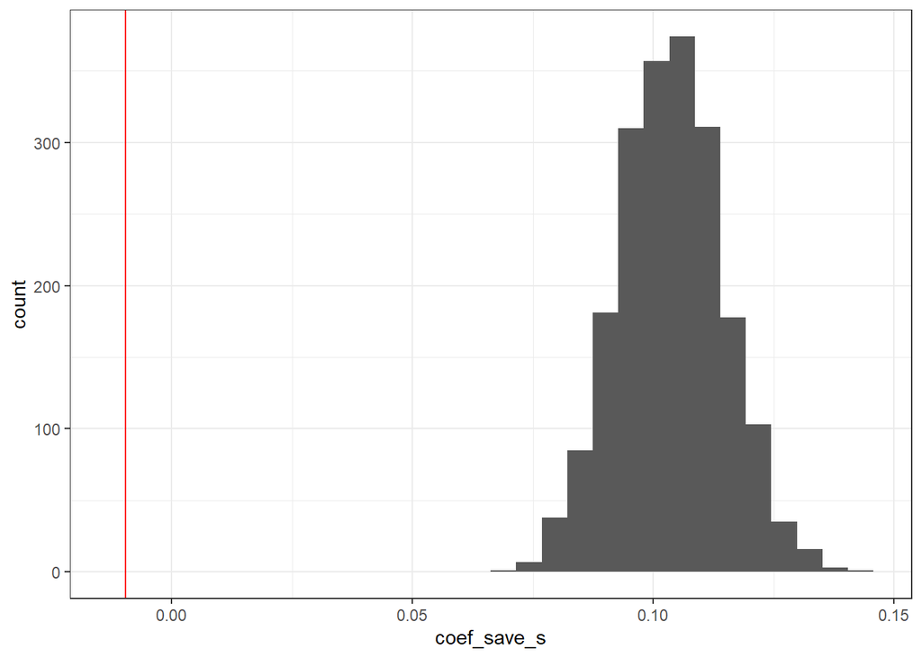

```r
# plot
ggplot(s_slope_dist, aes(x = coef_save_s)) +
  geom_histogram() +
  geom_vline(xintercept = coef(mod_s)[2], color = "red") +
  theme_bw()
```

```r
# W/2L------------------------------------------------------------------------
nsim = 20 #sample.size = how many values to generate at each time step
time = seq(0, 11.552685, length.out = 20) #nsim = 10 equidistent time steps (defined by length.out)
# greatest phyol_dist is 11.552685)

runs = 2000 # how many times to run sim -> extract slope from it

# Setup storage vectors
int_save_W_2L = coef_save_W_2L = numeric(runs)

for (k in 1:runs) {
  for (i in seq_along(time)) {
    # simulate 20 values using fold norm distribution
    test <- rfoldnorm(nsim, mean = 0, sd = sqrt(time[i] * W_2L_sd$s2))

    # Save to row i of the matrix
    morpho_dist_matrix[i, ] <- test

  }
  # store row/col names
  morpho_df_W_2L <- as.data.frame(morpho_dist_matrix)
  rownames(morpho_df_W_2L) <- paste0("time_", round(time, 2))
  colnames(morpho_df_W_2L) <- paste0("sim_", 1:nsim)

  # then make it into a df
  morpho_sim_W_2L <- morpho_df_W_2L %>%
    mutate(across(everything(), ~replace_na(., 0))) %>%
    rownames_to_column() %>%
    mutate(time = rowname) %>%
    pivot_longer(cols = sim_1:sim_20) %>%
    mutate(time = str_remove(time, "time_")) %>%
    select(!rowname) %>%
    rename(phylo_dist = time, morpho_dist = value) %>%
    mutate(phylo_dist = as.numeric(phylo_dist))

  # Model
  model = lm(morpho_dist ~ phylo_dist, data = morpho_sim_W_2L)
  # save slope and p value
  int_save_W_2L[k] = coef(model)[1]  #save the intercept value for the treatment
  coef_save_W_2L[k] = coef(model)[2] #save the slope estimate
}

W_2L_slope_dist <- data.frame(int_save_W_2L, coef_save_W_2L) # save slope + intercept in df

# cumulative dist function to find probability of observing real slope
# P(x<=mean) = pnorm(x)
mean_W_2L_sim <- mean(W_2L_slope_dist$coef_save_W_2L)
sd_W_2L_sim <- sd(W_2L_slope_dist$coef_save_W_2L)

pnorm(coef(mod_W_2L)[2], mean = mean_W_2L_sim, sd = sd_W_2L_sim)
```

```
##   phylo_dist
## 1.736956e-06
```

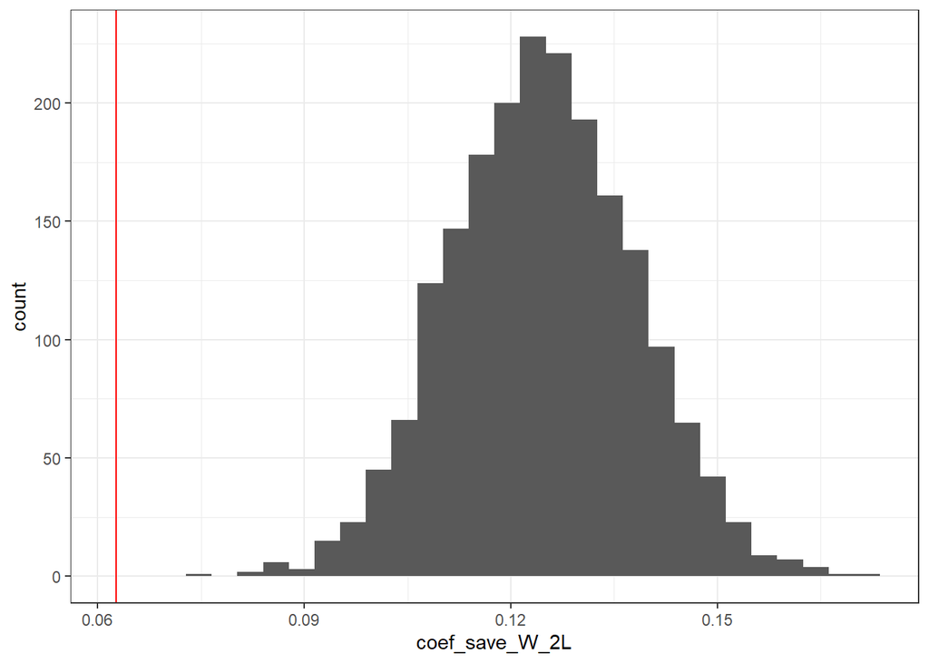

```r
# plot
ggplot(W_2L_slope_dist, aes(x = coef_save_W_2L)) +
  geom_histogram() +
  geom_vline(xintercept = coef(mod_W_2L)[2], color = "red") +
  theme_bw()
```

Both S and W/2L have much lower slopes than the brownian expectation. This is especially true for S. Both are also nearer to 0 than the average of the brownian slopes This seems to imply that there is a weaker relationship between phylogenetic distance and morphology than should be expected. This makes sense, as this means forces other than phylogenetic history are shaping the bill morphology of the honeycreepers, something we already assume to be true per their status as an adaptive radiation

# Plots

## Sharpening rate (s)

### Just real data

#### Plain data

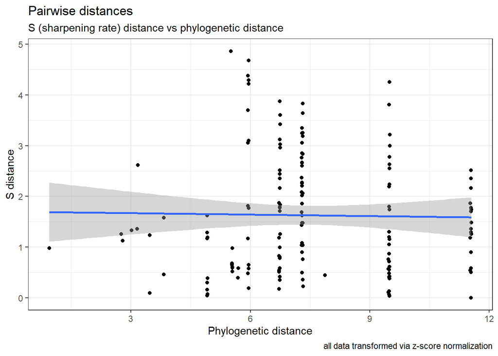

```r
# s-----------------------------
ggplot(s_3d_phylo, aes(x = phylo_dist, y = s_dist)) +
  geom_point() +
  geom_smooth(method = 'lm') +
  labs(title = "Pairwise distances",
       subtitle = "S (sharpening rate) distance vs phylogenetic distance",
       caption = "all data transformed via z-score normalization",
       x = "Phylogenetic distance",
       y = "S distance"
       ) +
  theme_bw()
```

#### Diff per sp, plotted on phylogeny

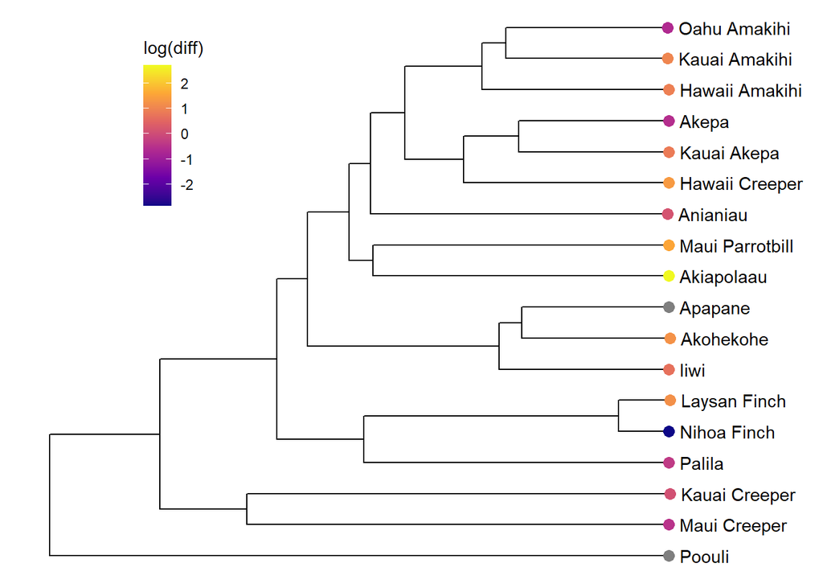

```r
# remove underscore from tip names
tree_3d$tip.label <- str_replace(tree_3d$tip.label, "_", " ")

# make diff on log scale (bc akiapolaau is too crazy high)
s_greater_bm_by_sp_log <- s_greater_bm_by_sp %>%
  mutate(diff = log(diff)) %>%
  rename(label = sp) %>% # tip label col must be named label for ggtree
  mutate(label = str_replace(label, "_", " ")) %>%
  mutate(label = str_to_title(label))

# plot
p <- ggtree(tree_3d) %<+% s_greater_bm_by_sp_log +
  geom_label(aes(label = label), label.size = NA, color = "black", hjust = 0, nudge_x = 0.05) +
  geom_tippoint(aes(color = diff), shape = 16, size = 3) +
  scale_color_viridis_c(option = "plasma", name = "log(diff)") +
  theme(legend.position=c(.2, .8))

p + xlim(0, max(p$data$x, na.rm = TRUE) + 1) # the labels keep hanging off
```

grey = no diff from null The akiapolaau has the highest difference in sharpening rate from the brownian expectation (15.09877201). No strong trends/phylogenetic groupings of difference. However, the poouli, the oldest split species, does not fall outside of the 95% quantile of the brownian null.

#### Diff per diet

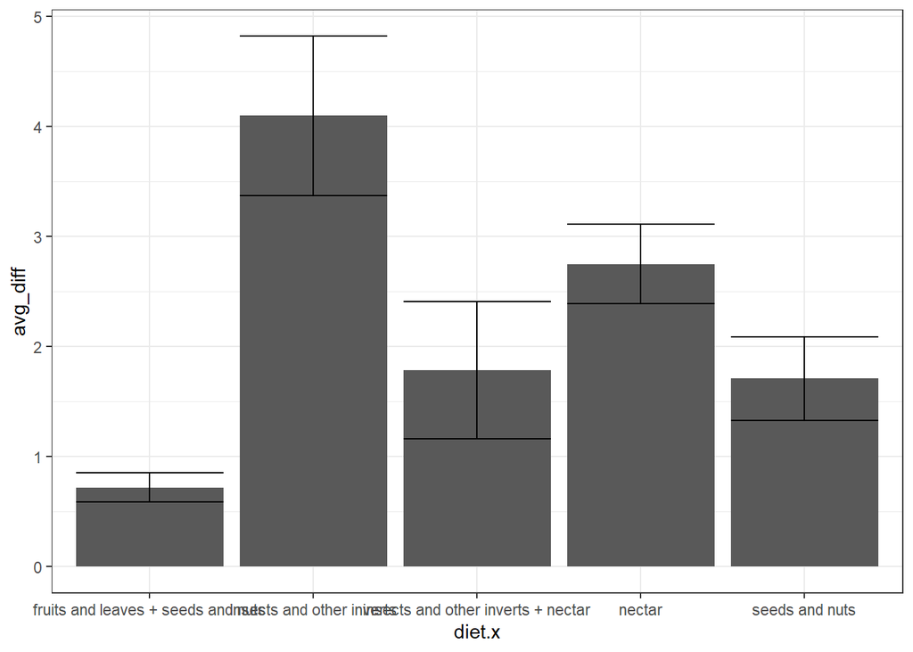

```r
ggplot(s_greater_bm_diet, aes(x = diet.x, y = avg_diff)) +
  geom_col() +
  geom_errorbar(aes(ymin = (avg_diff - stdev), ymax = (avg_diff + stdev))) +
  theme_bw()
```

### + brownian data

#### Brownian quantile overlay

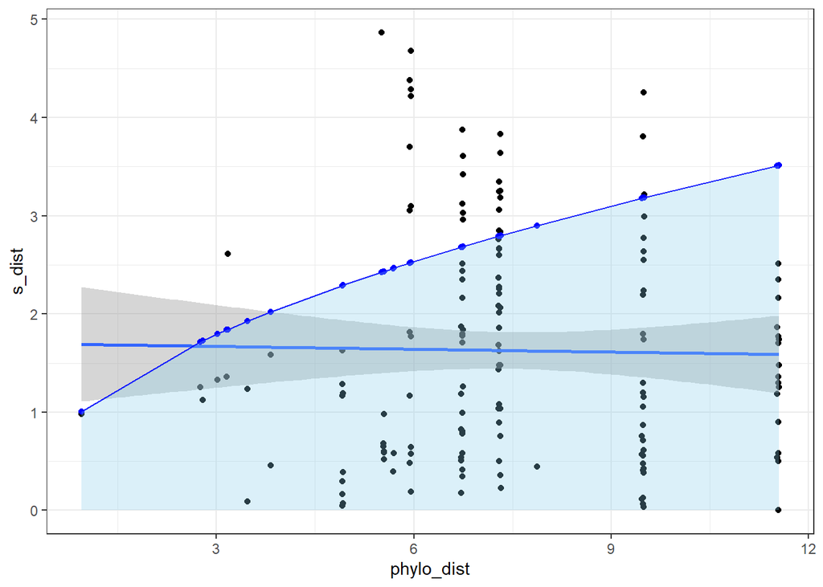

```r
ggplot() +
  geom_point(s_3d_phylo, mapping = aes(x = phylo_dist, y = s_dist))+
  geom_smooth(s_3d_phylo, mapping = aes(x = phylo_dist, y = s_dist), method = 'lm') +
  geom_point(bm_s, mapping = aes(x = phylo_dist, y = morpho_dist), color = "blue") +
  geom_line(bm_s, mapping = aes(x = phylo_dist, y = morpho_dist), color = "blue") +
  geom_area(bm_s, mapping = aes(x = phylo_dist, y = morpho_dist), fill = "skyblue", alpha = .3)+
  theme_bw()
```

#### Brownian trend line overlay

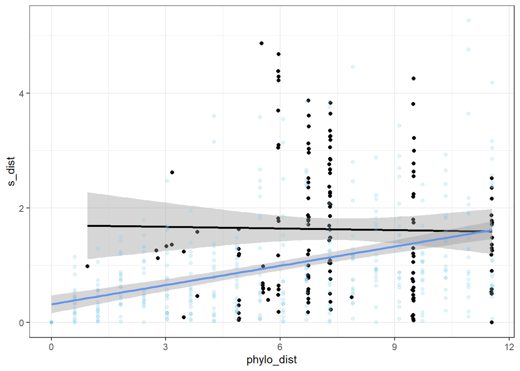

```r
ggplot() +
  geom_point(s_3d_phylo, mapping = aes(x = phylo_dist, y = s_dist))+
  geom_smooth(s_3d_phylo, mapping = aes(x = phylo_dist, y = s_dist), method = 'lm', color = "black") +
  geom_point(morpho_sim_s, mapping = aes(x = phylo_dist, y = morpho_dist), color = "skyblue", alpha = .25)+
  geom_smooth(morpho_sim_s, mapping = aes(x = phylo_dist, y = morpho_dist), color = "cornflowerblue", method = "lm") +
  theme_bw()
```

#### Brownian quantile + trend line overlay

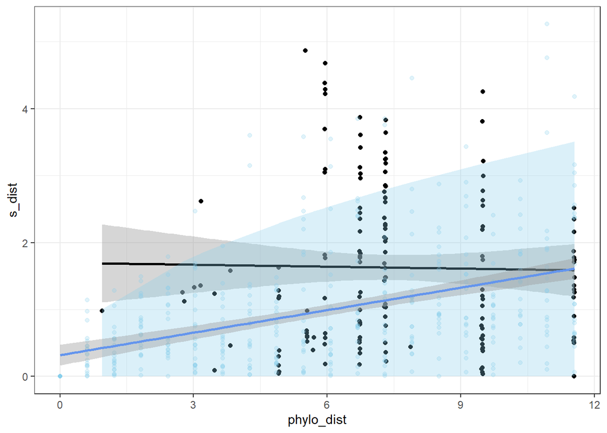

```r
ggplot() +
  geom_point(s_3d_phylo, mapping = aes(x = phylo_dist, y = s_dist))+
  geom_smooth(s_3d_phylo, mapping = aes(x = phylo_dist, y = s_dist), method = 'lm', color = "black") +
  geom_area(bm_s, mapping = aes(x = phylo_dist, y = morpho_dist), fill = "skyblue", alpha = .3) +
  geom_point(morpho_sim_s, mapping = aes(x = phylo_dist, y = morpho_dist), color = "skyblue", alpha = .25)+
  geom_smooth(morpho_sim_s, mapping = aes(x = phylo_dist, y = morpho_dist), color = "cornflowerblue", method = "lm") +
  theme_bw()
```

#### Brownian slope probability distribution with honeycreeper slope marked

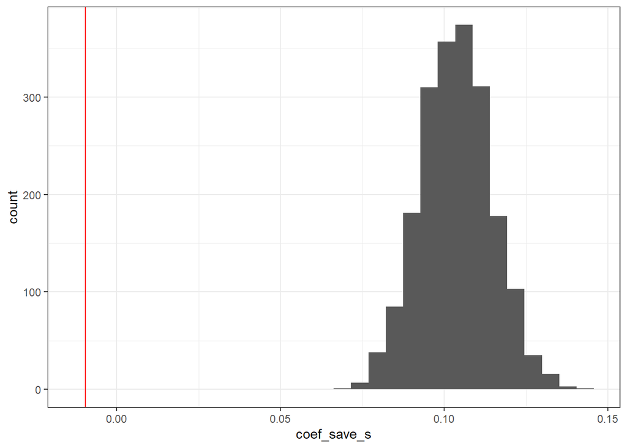

```r
ggplot(s_slope_dist, aes(x = coef_save_s)) +
  geom_histogram() +
  geom_vline(xintercept = coef(mod_s)[2], color = "red") +
  theme_bw()
```

## Wc/2Lc

### Just real data

#### Plain diff

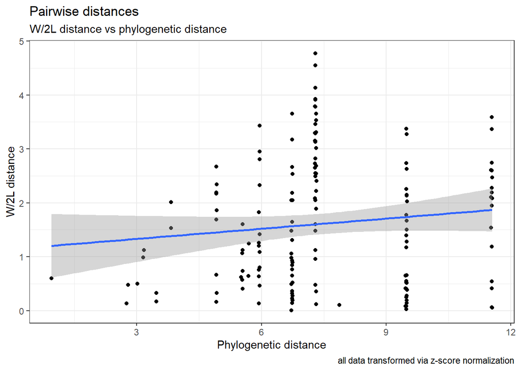

```r
ggplot(W_2L_3d_phylo, aes(x = phylo_dist, y = W_2L_dist)) +
  geom_point() +
  geom_smooth(method = 'lm') +
  labs(title = "Pairwise distances",
       subtitle = "W/2L distance vs phylogenetic distance",
       caption = "all data transformed via z-score normalization",
       x = "Phylogenetic distance",
       y = "W/2L distance"
       ) +
  theme_bw()
```

#### Diff per sp, plotted on phylogeny

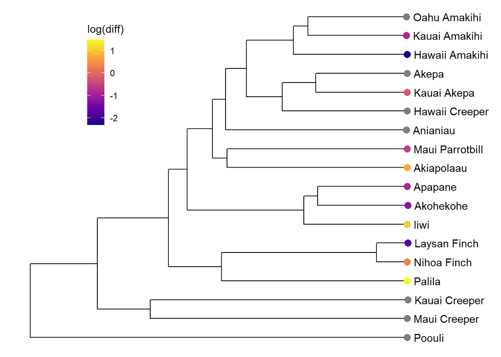

```r
# remove underscore from tip names
tree_3d$tip.label <- str_replace(tree_3d$tip.label, "_", " ")

# make diff on log scale (bc akiapolaau is too crazy high)
W_2L_greater_bm_by_sp_log <- W_2L_greater_bm_by_sp %>%
  mutate(diff = log(diff)) %>%
  rename(label = sp) %>% # tip label col must be named label for ggtree
  mutate(label = str_replace(label, "_", " ")) %>%
  mutate(label = str_to_title(label))

# plot
p <- ggtree(tree_3d) %<+% W_2L_greater_bm_by_sp_log +
  geom_label(aes(label = label), label.size = NA, color = "black", hjust = 0, nudge_x = 0.05) +
  geom_tippoint(aes(color = diff), shape = 16, size = 3) +
  scale_color_viridis_c(option = "plasma", name = "log(diff)") +
  theme(legend.position=c(.2, .8))

p + xlim(0, max(p$data$x, na.rm = TRUE) + 1) # the labels keep hanging off so putting a lil more space on x
```

grey = no dif from null The palila has the highest cumulative difference in w/2l from brownian null (4.41060632). There is not a strong apparent grouping for difference from brownian null. Even within the palila’s sister group of the nihoa and laysan finch, they vary greatly in difference. Again, the oldest-split species (poouli) is not different from brownian null.

#### Diff per diet

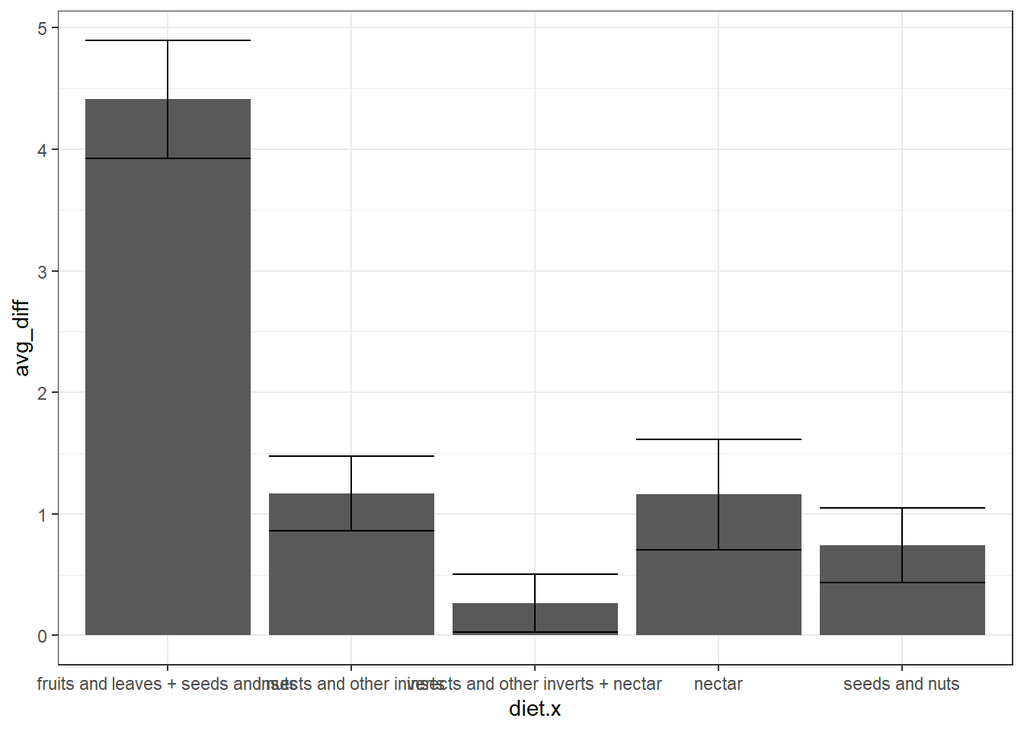

```r
ggplot(W_2L_bm_by_diet, aes(x = diet.x, y = avg_diff)) +
  geom_col() +
  geom_errorbar(aes(ymin = (avg_diff - stdev), ymax = (avg_diff + stdev))) +
  theme_bw()
```

### + brownian data

#### Brownian quantile overlay

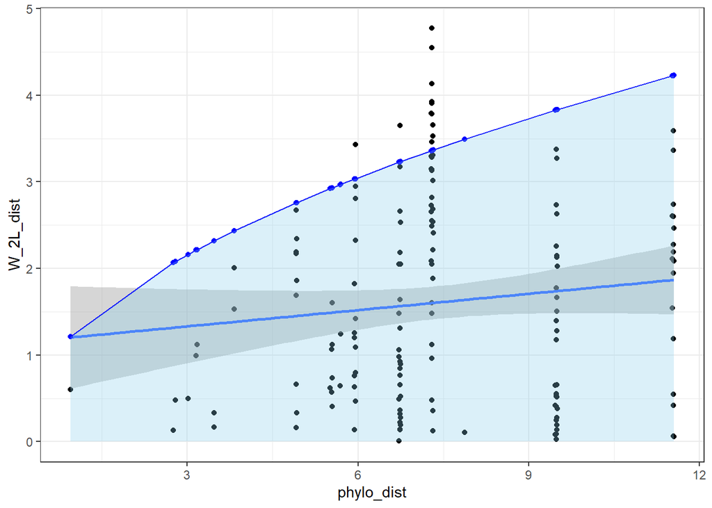

```r
ggplot() +
  geom_point(W_2L_3d_phylo, mapping = aes(x = phylo_dist, y = W_2L_dist))+
  geom_smooth(W_2L_3d_phylo, mapping = aes(x = phylo_dist, y = W_2L_dist), method = 'lm') +
  geom_point(bm_W_2L, mapping = aes(x = phylo_dist, y = morpho_dist), color = "blue") +
  geom_line(bm_W_2L, mapping = aes(x = phylo_dist, y = morpho_dist), color = "blue") +
  geom_area(bm_W_2L, mapping = aes(x = phylo_dist, y = morpho_dist), fill = "skyblue", alpha = .3) +
  theme_bw()
```

#### Brownian trend line overlay

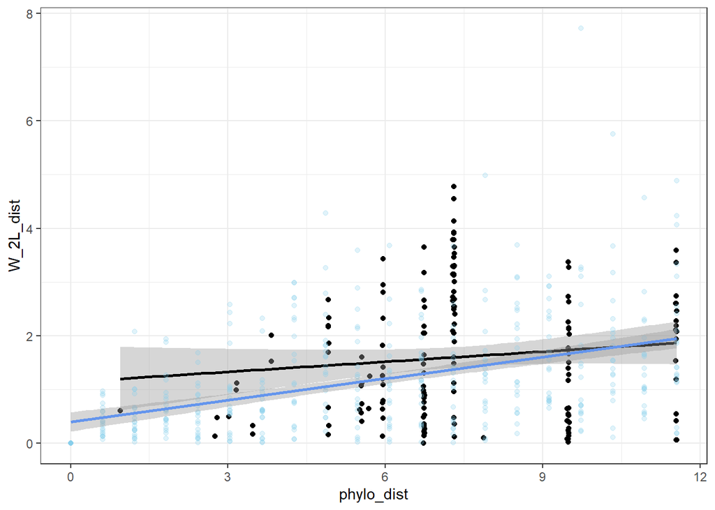

```r
ggplot() +
  geom_point(W_2L_3d_phylo, mapping = aes(x = phylo_dist, y = W_2L_dist))+
  geom_smooth(W_2L_3d_phylo, mapping = aes(x = phylo_dist, y = W_2L_dist), method = 'lm', color = "black") +
  geom_point(morpho_sim_W_2L, mapping = aes(x = phylo_dist, y = morpho_dist), color = "skyblue", alpha = .25)+
  geom_smooth(morpho_sim_W_2L, mapping = aes(x = phylo_dist, y = morpho_dist), color = "cornflowerblue", method = "lm") +
  theme_bw()
```

#### Brownian quantile + trend line overlay

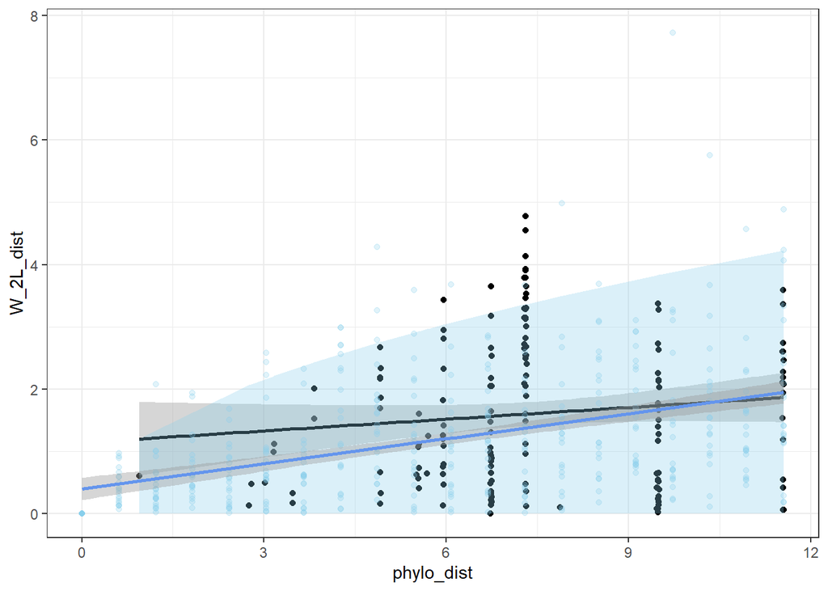

```r
ggplot() +
  geom_point(W_2L_3d_phylo, mapping = aes(x = phylo_dist, y = W_2L_dist))+
  geom_smooth(W_2L_3d_phylo, mapping = aes(x = phylo_dist, y = W_2L_dist), method = 'lm', color = "black") +
  geom_area(bm_W_2L, mapping = aes(x = phylo_dist, y = morpho_dist), fill = "skyblue", alpha = .3) +
  geom_point(morpho_sim_W_2L, mapping = aes(x = phylo_dist, y = morpho_dist), color = "skyblue", alpha = .25)+
  geom_smooth(morpho_sim_W_2L, mapping = aes(x = phylo_dist, y = morpho_dist), color = "cornflowerblue", method = "lm") +
  theme_bw()
```

#### Brownian slope probability distribution with honeycreeper slope marked

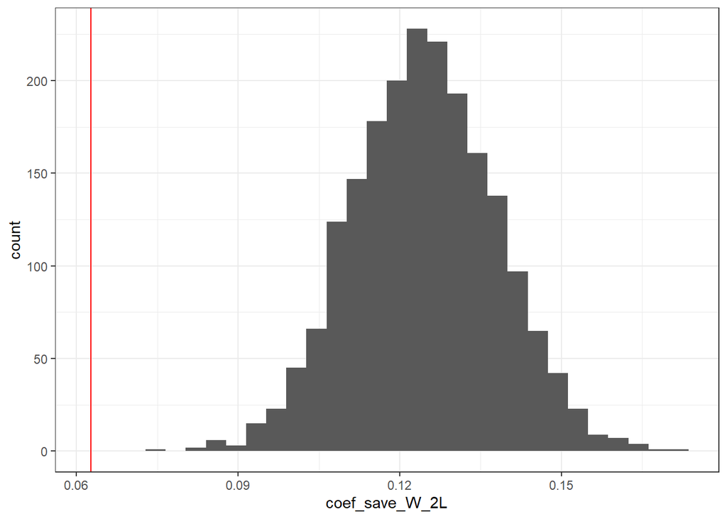

```r
ggplot(W_2L_slope_dist, aes(x = coef_save_W_2L)) +
  geom_histogram() +
  geom_vline(xintercept = coef(mod_W_2L)[2], color = "red") +
  theme_bw()
```